# AIML_ML_Project_full_code_notebookAlllifebank_pawan

## Model Performance Comparison and Final Model Selection

TEST MODEL PERFORMANCE (TEST DATA)

1. Model Performance using Confusion Matrix (Test data)

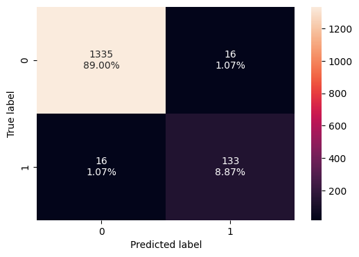

```python
#Checking Model performance on Test data
plot_confusion_matrix(dtree_model1, X_test, y_test)
```

2. Calculate Performance matrix (Accuracy, Recall, Precision, F1)

```python
decision_tree_perf_test = model_performance_classification(dtree_model1, X_test, y_test) ## Complete the code to check performance on test data
decision_tree_perf_test
```

|  | Accuracy | Recall | Precision | F1 |
| --- | --- | --- | --- | --- |
| 0 | 0.978667 | 0.892617 | 0.892617 | 0.892617 |

**Observations**

- There is slight drop in Recall, Precision and F1 in test data (compared to train data)

**Pre Pruning**

```python
depth = dtree_model1.get_depth()

print(f"The depth of the decision tree is: {depth}")
print(f"The number of nodes in the tree is: {dtree_model1.tree_.node_count}")
```

```
The depth of the decision tree is: 11
The number of nodes in the tree is: 95
```

** Observation**

- Original tree created is too complex. We will use pre pruning technique to make it less complex.

```python
max_depth_values = np.arange(2, 11, 2) #output [2,4,6,8,10]
max_leaf_nodes_values = np.arange(10, 51, 10)  #output [10,20,30,40,50]
min_samples_split_values = np.arange(10, 51, 10) #output [10,20,30,40,50]

# initialize variables to store the best model and its performance
best_estimator = None
best_score_diff = float('inf')
best_test_score = 0.0

# iterate over all combinations of the specified parameter values
for max_depth in max_depth_values:
    for max_leaf_nodes in max_leaf_nodes_values:
        for min_samples_split in min_samples_split_values:

            # initialize the tree with the current set of parameters
            estimator = DecisionTreeClassifier(
                max_depth=max_depth,
                max_leaf_nodes=max_leaf_nodes,
                min_samples_split=min_samples_split,
                random_state=42
            )

            # fit the model to the training data
            estimator.fit(X_train, y_train)

            # make predictions on the training and test sets
            y_train_pred = estimator.predict(X_train)
            y_test_pred = estimator.predict(X_test)

            # calculate F1 scores for training and test sets
            train_f1_score = f1_score(y_train, y_train_pred)
            test_f1_score = f1_score(y_test, y_test_pred)

            # calculate the absolute difference between training and test F1 scores
            score_diff = abs(train_f1_score - test_f1_score)

            # update the best estimator and best score if the current one has a smaller score difference
            if score_diff < best_score_diff:
                best_score_diff = score_diff
                best_estimator = estimator
```

```python
# Print the best parameters
print("Best parameters:")
print(f"Max depth: {best_estimator.max_depth}")
print(f"Max leaf nodes: {best_estimator.max_leaf_nodes}")
print(f"Min samples split: {best_estimator.min_samples_split}")
print(f"Best test recall score: {best_test_score}")
```

```
Best parameters:
Max depth: 6
Max leaf nodes: 20
Min samples split: 50
Best test recall score: 0.0
```

** Observations **

- Best optimized parameters for the tree are max depth=6, max leaf nodes = 20
- Minimum samples split = 50

```python
# creating an instance of the best model
dtree_model2 = best_estimator

# fitting the best model to the training data
dtree_model2.fit(X_train, y_train)
```

```
DecisionTreeClassifier(max_depth=np.int64(6), max_leaf_nodes=np.int64(20),
                       min_samples_split=np.int64(50), random_state=42)
```

**Checking performance on training data Model 2 after pre-pruning**

1. Model Performance using Confusion Matrix - dtree_model2

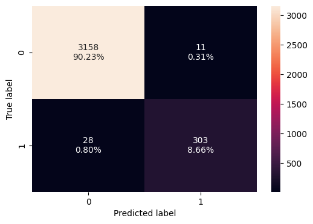

```python
plot_confusion_matrix(dtree_model2, X_train, y_train)
```

2. Calculate Performance matrix (Accuracy, Recall, Precision, F1)

```python
dtree2_train_perf_tuned = model_performance_classification(
    dtree_model2, X_train, y_train
)
dtree2_train_perf_tuned
```

|  | Accuracy | Recall | Precision | F1 |
| --- | --- | --- | --- | --- |
| 0 | 0.988857 | 0.915408 | 0.964968 | 0.939535 |

**Observations**

- We see that the F1 score is slighlty dropped from 1 to 0.94 after pre-pruning, but the complexity of the tree is significantly reduced.
- We see similar drop in Accuracy and Recall (from 1 to 0.989 for Accuracy and from 1 to 0.915 for Recall). The srop is non-significant, but it reduces the complexity of tree significantly
3. Visualize this model2 tree

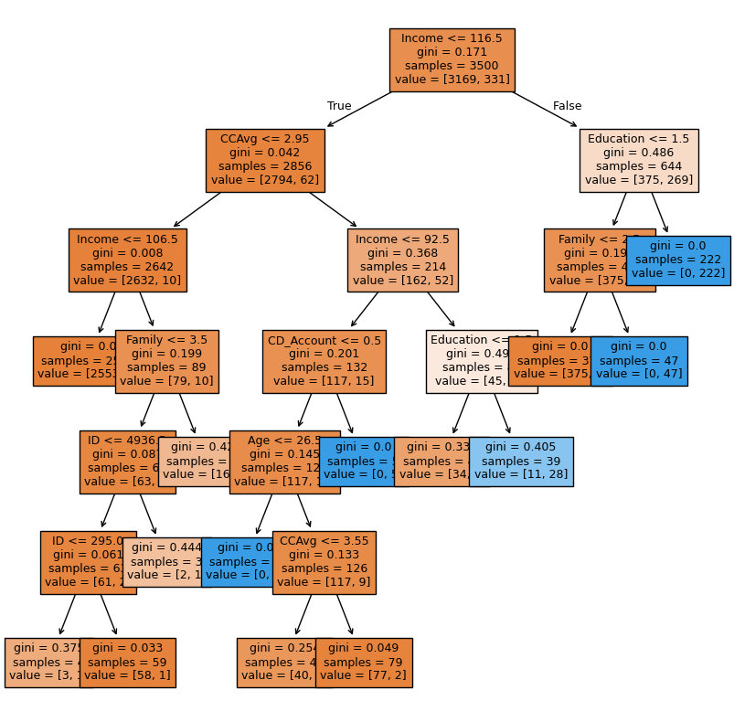

```python
plt.figure(figsize=(10, 10))
out = tree.plot_tree(
    dtree_model2,
    feature_names=feature_names,
    filled=True,
    fontsize=9,
    node_ids=False,
    class_names=None,
)
# below code will add arrows to the decision tree split if they are missing
for o in out:
    arrow = o.arrow_patch
    if arrow is not None:
        arrow.set_edgecolor("black")
        arrow.set_linewidth(1)
plt.show()
```

4. Show the rules of a decision tree in Text format

```python
# Text report showing the rules of a decision tree -

print(tree.export_text(dtree_model2, feature_names=feature_names, show_weights=True))
```

```
|--- Income <= 116.50
|   |--- CCAvg <= 2.95
|   |   |--- Income <= 106.50
|   |   |   |--- weights: [2553.00, 0.00] class: 0
|   |   |--- Income >  106.50
|   |   |   |--- Family <= 3.50
|   |   |   |   |--- ID <= 4936.50
|   |   |   |   |   |--- ID <= 295.00
|   |   |   |   |   |   |--- weights: [3.00, 1.00] class: 0
|   |   |   |   |   |--- ID >  295.00
|   |   |   |   |   |   |--- weights: [58.00, 1.00] class: 0
|   |   |   |   |--- ID >  4936.50
|   |   |   |   |   |--- weights: [2.00, 1.00] class: 0
|   |   |   |--- Family >  3.50
|   |   |   |   |--- weights: [16.00, 7.00] class: 0
|   |--- CCAvg >  2.95
|   |   |--- Income <= 92.50
|   |   |   |--- CD_Account <= 0.50
|   |   |   |   |--- Age <= 26.50
|   |   |   |   |   |--- weights: [0.00, 1.00] class: 1
|   |   |   |   |--- Age >  26.50
|   |   |   |   |   |--- CCAvg <= 3.55
|   |   |   |   |   |   |--- weights: [40.00, 7.00] class: 0
|   |   |   |   |   |--- CCAvg >  3.55
|   |   |   |   |   |   |--- weights: [77.00, 2.00] class: 0
|   |   |   |--- CD_Account >  0.50
|   |   |   |   |--- weights: [0.00, 5.00] class: 1
|   |   |--- Income >  92.50
|   |   |   |--- Education <= 1.50
|   |   |   |   |--- weights: [34.00, 9.00] class: 0
|   |   |   |--- Education >  1.50
|   |   |   |   |--- weights: [11.00, 28.00] class: 1
|--- Income >  116.50
|   |--- Education <= 1.50
|   |   |--- Family <= 2.50
|   |   |   |--- weights: [375.00, 0.00] class: 0
|   |   |--- Family >  2.50
|   |   |   |--- weights: [0.00, 47.00] class: 1
|   |--- Education >  1.50
|   |   |--- weights: [0.00, 222.00] class: 1
```

5. Review Gini scores

```python
# Text report showing the rules of a decision tree -

print(tree.export_text(dtree_model2, feature_names=feature_names, show_weights=True))
```

```
|--- Income <= 116.50
|   |--- CCAvg <= 2.95
|   |   |--- Income <= 106.50
|   |   |   |--- weights: [2553.00, 0.00] class: 0
|   |   |--- Income >  106.50
|   |   |   |--- Family <= 3.50
|   |   |   |   |--- ID <= 4936.50
|   |   |   |   |   |--- ID <= 295.00
|   |   |   |   |   |   |--- weights: [3.00, 1.00] class: 0
|   |   |   |   |   |--- ID >  295.00
|   |   |   |   |   |   |--- weights: [58.00, 1.00] class: 0
|   |   |   |   |--- ID >  4936.50
|   |   |   |   |   |--- weights: [2.00, 1.00] class: 0
|   |   |   |--- Family >  3.50
|   |   |   |   |--- weights: [16.00, 7.00] class: 0
|   |--- CCAvg >  2.95
|   |   |--- Income <= 92.50
|   |   |   |--- CD_Account <= 0.50
|   |   |   |   |--- Age <= 26.50
|   |   |   |   |   |--- weights: [0.00, 1.00] class: 1
|   |   |   |   |--- Age >  26.50
|   |   |   |   |   |--- CCAvg <= 3.55
|   |   |   |   |   |   |--- weights: [40.00, 7.00] class: 0
|   |   |   |   |   |--- CCAvg >  3.55
|   |   |   |   |   |   |--- weights: [77.00, 2.00] class: 0
|   |   |   |--- CD_Account >  0.50
|   |   |   |   |--- weights: [0.00, 5.00] class: 1
|   |   |--- Income >  92.50
|   |   |   |--- Education <= 1.50
|   |   |   |   |--- weights: [34.00, 9.00] class: 0
|   |   |   |--- Education >  1.50
|   |   |   |   |--- weights: [11.00, 28.00] class: 1
|--- Income >  116.50
|   |--- Education <= 1.50
|   |   |--- Family <= 2.50
|   |   |   |--- weights: [375.00, 0.00] class: 0
|   |   |--- Family >  2.50
|   |   |   |--- weights: [0.00, 47.00] class: 1
|   |--- Education >  1.50
|   |   |--- weights: [0.00, 222.00] class: 1
```

6. Feature Importance

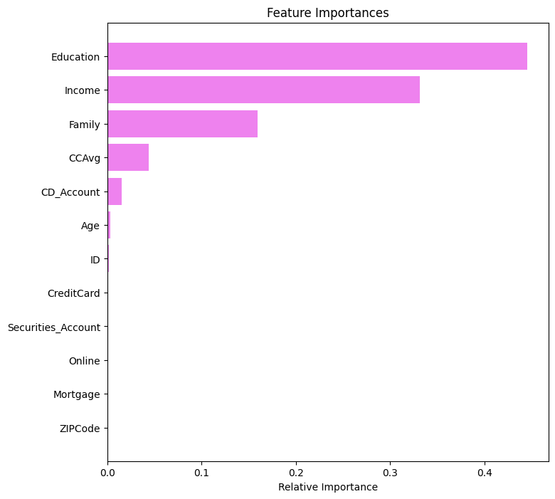

```python
# importance of features in the tree building
importances = dtree_model2.feature_importances_
indices = np.argsort(importances)

plt.figure(figsize=(8, 8))
plt.title("Feature Importances")
plt.barh(range(len(indices)), importances[indices], color="violet", align="center")
plt.yticks(range(len(indices)), [feature_names[i] for i in indices])
plt.xlabel("Relative Importance")
plt.show()
```

** Observations **

- The above result shows that top three fields contributes 92% importance in model building (Education, Income, Family)
- CCAvg is also a contributer (4.4%) and is also directly correlated with Personal_Loan as seen in correlation matrix in prior EDA step.
7. Checking performance on test data

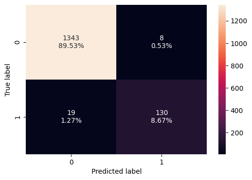

```python
plot_confusion_matrix(dtree_model2, X_test, y_test)
```

8. Calculate Performance matrix (Accuracy, Recall, Precision, F1)

```python
decision_tree_perf_test_tuned = model_performance_classification(dtree_model2, X_test, y_test)
decision_tree_perf_test_tuned
```

|  | Accuracy | Recall | Precision | F1 |
| --- | --- | --- | --- | --- |
| 0 | 0.982 | 0.872483 | 0.942029 | 0.905923 |

** Observation **

- With pre-pruning, the model has improved the Accuracy, Precision and F1 score on test data.
- There is slight dip in recall value (0.89 to 0.87) on test data, but overall tree is much simpler.

**Post-Pruning**

```python
# Create an instance of the decision tree model
clf = DecisionTreeClassifier(random_state=1)  #Creates model with random state = 1 for preserving the original randomness

# Compute the cost complexity pruning path for the model using the training data
path = clf.cost_complexity_pruning_path(X_train, y_train)

# Extract the array of effective alphas from the pruning path
ccp_alphas = abs(path.ccp_alphas)

# Extract the array of total impurities at each alpha along the pruning path
impurities = path.impurities
```

```python
pd.DataFrame(path)
```

|  | ccp_alphas | impurities |
| --- | --- | --- |
| 0 | 0.000000 | 0.000000 |
| 1 | 0.000187 | 0.000562 |
| 2 | 0.000223 | 0.001676 |
| 3 | 0.000264 | 0.002203 |
| 4 | 0.000268 | 0.003277 |
| 5 | 0.000269 | 0.004351 |
| 6 | 0.000359 | 0.005427 |
| 7 | 0.000381 | 0.005808 |
| 8 | 0.000381 | 0.006189 |
| 9 | 0.000476 | 0.006665 |
| 10 | 0.000484 | 0.007150 |
| 11 | 0.000527 | 0.007677 |
| 12 | 0.000582 | 0.008259 |
| 13 | 0.000769 | 0.011336 |
| 14 | 0.000777 | 0.013668 |
| 15 | 0.000788 | 0.014456 |
| 16 | 0.000882 | 0.017985 |
| 17 | 0.001552 | 0.019536 |
| 18 | 0.002333 | 0.021869 |
| 19 | 0.003024 | 0.024893 |
| 20 | 0.003294 | 0.028187 |
| 21 | 0.006473 | 0.034659 |
| 22 | 0.023866 | 0.058525 |
| 23 | 0.056365 | 0.171255 |

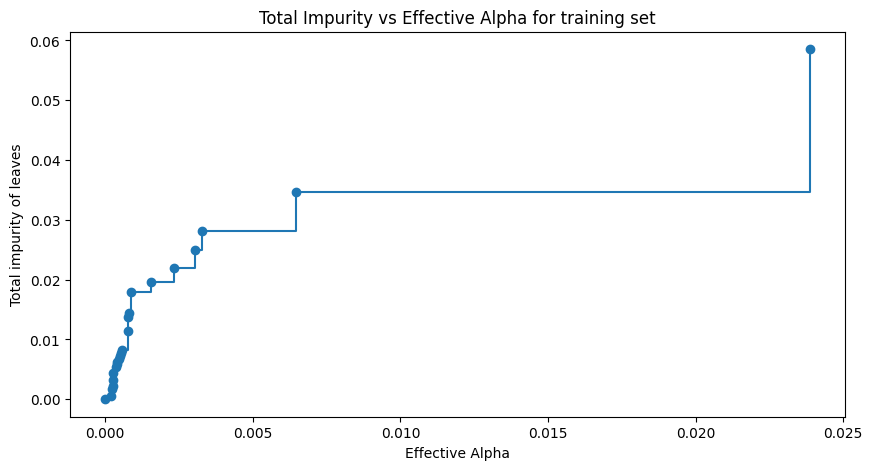

```python
# Create a figure
fig, ax = plt.subplots(figsize=(10, 5))

# Plot the total impurities versus effective alphas, excluding the last value,
# using markers at each data point and connecting them with steps
ax.plot(ccp_alphas[:-1], impurities[:-1], marker="o", drawstyle="steps-post")

# Set the x-axis label
ax.set_xlabel("Effective Alpha")

# Set the y-axis label
ax.set_ylabel("Total impurity of leaves")

# Set the title of the plot
ax.set_title("Total Impurity vs Effective Alpha for training set");
```

** Observation **

- Train a decision tree using effective alphas. The last value in ccp_alphas is the alpha value that prunes the whole tree, leaving the tree, clfs[-1], with one node.

```python
# Initialize an empty list to store the decision tree classifiers
clfs = []

# Iterate over each ccp_alpha value extracted from cost complexity pruning path
for ccp_alpha in ccp_alphas:
    # Create an instance of the DecisionTreeClassifier
    clf = DecisionTreeClassifier(ccp_alpha=ccp_alpha, random_state=1)

    # Fit the classifier to the training data
    clf.fit(X_train, y_train)

    # Append the trained classifier to the list
    clfs.append(clf)

# Print the number of nodes in the last tree along with its ccp_alpha value
print(
    "Number of nodes in the last tree is {} with ccp_alpha {}".format(
        clfs[-1].tree_.node_count, ccp_alphas[-1]
    )
)
```

```
Number of nodes in the last tree is 1 with ccp_alpha 0.056364969335601575
```

Observation: Remove the last element in clfs and ccp_alphas as it corresponds to a trivial tree with only one node.

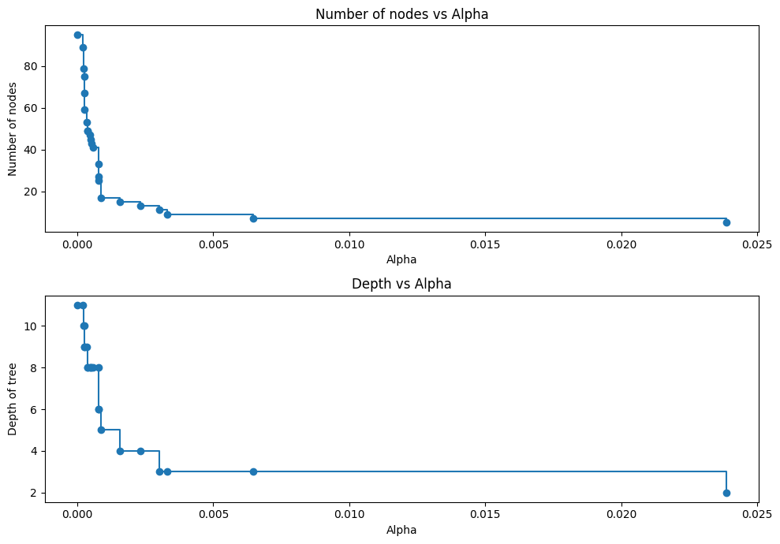

```python
# Remove the last classifier and corresponding ccp_alpha value from the lists
clfs = clfs[:-1]
ccp_alphas = ccp_alphas[:-1]

# Extract the number of nodes in each tree classifier
node_counts = [clf.tree_.node_count for clf in clfs]

# Extract the maximum depth of each tree classifier
depth = [clf.tree_.max_depth for clf in clfs]

# Create a figure and a set of subplots
fig, ax = plt.subplots(2, 1, figsize=(10, 7))

# Plot the number of nodes versus ccp_alphas on the first subplot
ax[0].plot(ccp_alphas, node_counts, marker="o", drawstyle="steps-post")
ax[0].set_xlabel("Alpha")
ax[0].set_ylabel("Number of nodes")
ax[0].set_title("Number of nodes vs Alpha")

# Plot the depth of tree versus ccp_alphas on the second subplot
ax[1].plot(ccp_alphas, depth, marker="o", drawstyle="steps-post")
ax[1].set_xlabel("Alpha")
ax[1].set_ylabel("Depth of tree")
ax[1].set_title("Depth vs Alpha")

# Adjust the layout of the subplots to avoid overlap
fig.tight_layout()
```

```python
train_f1_scores = []  # Initialize an empty list to store F1 scores for training set for each decision tree classifier

# Iterate through each decision tree classifier in 'clfs'
for clf in clfs:
    # Predict labels for the training set using the current decision tree classifier
    pred_train = clf.predict(X_train)

    # Calculate the F1 score for the training set predictions compared to true labels
    f1_train = f1_score(y_train, pred_train)

    # Append the calculated F1 score to the train_f1_scores list
    train_f1_scores.append(f1_train)
```

```python
test_f1_scores = []  # Initialize an empty list to store F1 scores for test set for each decision tree classifier

# Iterate through each decision tree classifier in 'clfs'
for clf in clfs:
    # Predict labels for the test set using the current decision tree classifier
    pred_test = clf.predict(X_test)

    # Calculate the F1 score for the test set predictions compared to true labels
    f1_test = f1_score(y_test, pred_test)

    # Append the calculated F1 score to the test_f1_scores list
    test_f1_scores.append(f1_test)
```

```python
# Create a figure
fig, ax = plt.subplots(figsize=(15, 5))
ax.set_xlabel("Alpha")  # Set the label for the x-axis
ax.set_ylabel("F1 Score")  # Set the label for the y-axis
ax.set_title("F1 Score vs Alpha for training and test sets")  # Set the title of the plot

# Plot the training F1 scores against alpha, using circles as markers and steps-post style
ax.plot(ccp_alphas, train_f1_scores, marker="o", label="training", drawstyle="steps-post")

# Plot the testing F1 scores against alpha, using circles as markers and steps-post style
ax.plot(ccp_alphas, test_f1_scores, marker="o", label="test", drawstyle="steps-post")

ax.legend();  # Add a legend to the plot
```

[output not shown]

Create a model with highest F1 score

```python
# creating the model where we get highest test F1 Score
index_best_model = np.argmax(test_f1_scores)

# selcting the decision tree model corresponding to the highest test score
dtree_model3 = clfs[index_best_model]
print(dtree_model3)
```

```
DecisionTreeClassifier(ccp_alpha=np.float64(0.00048443223443223483),
                       random_state=1)
```

**Model Performance using Confusion Matrix-Training Set**

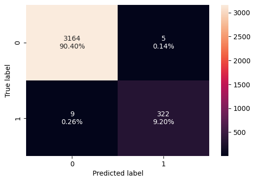

```python
plot_confusion_matrix(dtree_model3, X_train, y_train)
```

** Calculate Performance Matrix (Accurancy, Recall, performance and F1**

```python
dtree3_train_perf_tuned = model_performance_classification(
    dtree_model3, X_train, y_train
)
dtree3_train_perf_tuned
```

|  | Accuracy | Recall | Precision | F1 |
| --- | --- | --- | --- | --- |
| 0 | 0.996 | 0.97281 | 0.984709 | 0.978723 |

** Observation **

- The post-pruning has improved the Accuracy, Recall, Precision and F1 scores on training data as compared to pre-pruning model.

** Visualize the tree **

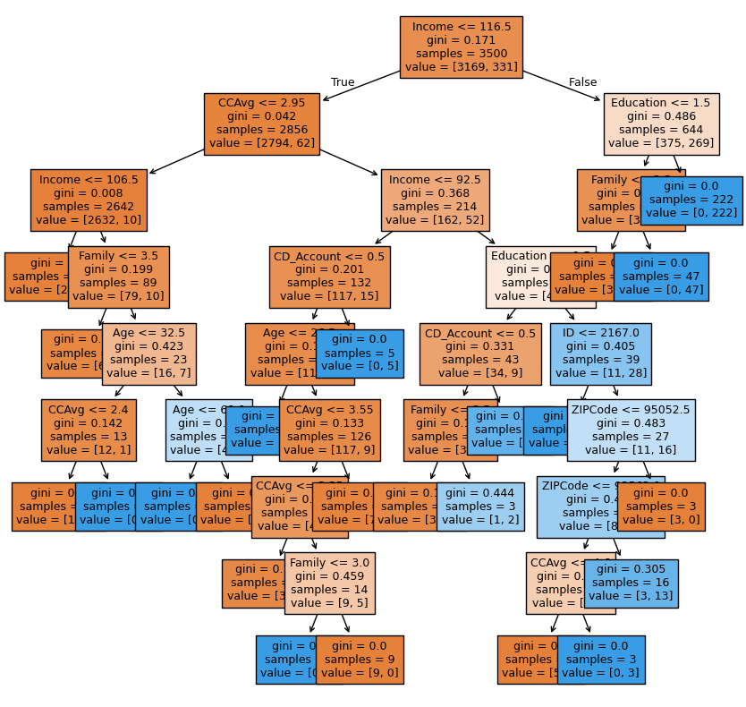

```python
plt.figure(figsize=(10, 10))
out = tree.plot_tree(
    dtree_model3,
    feature_names=feature_names,
    filled=True,
    fontsize=9,
    node_ids=False,
    class_names=None,
)
# below code will add arrows to the decision tree split if they are missing
for o in out:
    arrow = o.arrow_patch
    if arrow is not None:
        arrow.set_edgecolor("black")
        arrow.set_linewidth(1)
plt.show()
```

** Show the tree in text format **

```python
print(tree.export_text(dtree_model3, feature_names=feature_names, show_weights=True))
```

```
|--- Income <= 116.50
|   |--- CCAvg <= 2.95
|   |   |--- Income <= 106.50
|   |   |   |--- weights: [2553.00, 0.00] class: 0
|   |   |--- Income >  106.50
|   |   |   |--- Family <= 3.50
|   |   |   |   |--- weights: [63.00, 3.00] class: 0
|   |   |   |--- Family >  3.50
|   |   |   |   |--- Age <= 32.50
|   |   |   |   |   |--- CCAvg <= 2.40
|   |   |   |   |   |   |--- weights: [12.00, 0.00] class: 0
|   |   |   |   |   |--- CCAvg >  2.40
|   |   |   |   |   |   |--- weights: [0.00, 1.00] class: 1
|   |   |   |   |--- Age >  32.50
|   |   |   |   |   |--- Age <= 60.00
|   |   |   |   |   |   |--- weights: [0.00, 6.00] class: 1
|   |   |   |   |   |--- Age >  60.00
|   |   |   |   |   |   |--- weights: [4.00, 0.00] class: 0
|   |--- CCAvg >  2.95
|   |   |--- Income <= 92.50
|   |   |   |--- CD_Account <= 0.50
|   |   |   |   |--- Age <= 26.50
|   |   |   |   |   |--- weights: [0.00, 1.00] class: 1
|   |   |   |   |--- Age >  26.50
|   |   |   |   |   |--- CCAvg <= 3.55
|   |   |   |   |   |   |--- CCAvg <= 3.35
|   |   |   |   |   |   |   |--- weights: [31.00, 2.00] class: 0
|   |   |   |   |   |   |--- CCAvg >  3.35
|   |   |   |   |   |   |   |--- Family <= 3.00
|   |   |   |   |   |   |   |   |--- weights: [0.00, 5.00] class: 1
|   |   |   |   |   |   |   |--- Family >  3.00
|   |   |   |   |   |   |   |   |--- weights: [9.00, 0.00] class: 0
|   |   |   |   |   |--- CCAvg >  3.55
|   |   |   |   |   |   |--- weights: [77.00, 2.00] class: 0
|   |   |   |--- CD_Account >  0.50
|   |   |   |   |--- weights: [0.00, 5.00] class: 1
|   |   |--- Income >  92.50
|   |   |   |--- Education <= 1.50
|   |   |   |   |--- CD_Account <= 0.50
|   |   |   |   |   |--- Family <= 3.50
```

[output cut: 12 more lines]

```
|   |   |   |   |   |   |   |   |--- weights: [5.00, 0.00] class: 0
|   |   |   |   |   |   |   |--- CCAvg >  4.60
|   |   |   |   |   |   |   |   |--- weights: [0.00, 3.00] class: 1
|   |   |   |   |   |   |--- ZIPCode >  92562.00
|   |   |   |   |   |   |   |--- weights: [3.00, 13.00] class: 1
|   |   |   |   |   |--- ZIPCode >  95052.50
|   |   |   |   |   |   |--- weights: [3.00, 0.00] class: 0
|--- Income >  116.50
|   |--- Education <= 1.50
|   |   |--- Family <= 2.50
|   |   |   |--- weights: [375.00, 0.00] class: 0
|   |   |--- Family >  2.50
|   |   |   |--- weights: [0.00, 47.00] class: 1
|   |--- Education >  1.50
|   |   |--- weights: [0.00, 222.00] class: 1
```

** Show Feature importance **

```python
# importance of features in the tree building ( The importance of a feature is computed as the
# (normalized) total reduction of the criterion brought by that feature. It is also known as the Gini importance )

print(
    pd.DataFrame(
        dtree_model3.feature_importances_, columns=["Imp"], index=X_train.columns
    ).sort_values(by="Imp", ascending=False)
)
```

```
                         Imp
Education           0.418420
Income              0.310791
Family              0.164150
CCAvg               0.053764
CD_Account          0.023672
Age                 0.016721
ZIPCode             0.007682
ID                  0.004801
Mortgage            0.000000
Securities_Account  0.000000
Online              0.000000
CreditCard          0.000000
```

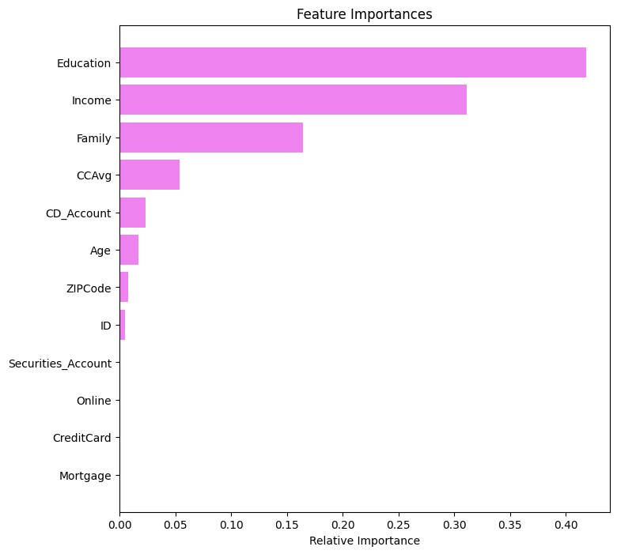

```python
# importance of features in the tree building
importances = dtree_model3.feature_importances_
indices = np.argsort(importances)

plt.figure(figsize=(8, 8))
plt.title("Feature Importances")
plt.barh(range(len(indices)), importances[indices], color="violet", align="center")
plt.yticks(range(len(indices)), [feature_names[i] for i in indices])
plt.xlabel("Relative Importance")
plt.show()
```

** Observations **

- After post-pruning, Education, Income and Family are the most influential attributes that contributes to ~88% importance in determining loan approval decision

** Test the model3 on test data **

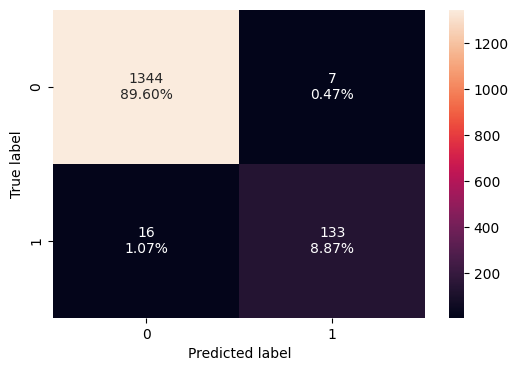

```python
plot_confusion_matrix(dtree_model3, X_test, y_test)
```

** Observations **

```python
dtree3_test_perf_tuned_post1 = model_performance_classification(
    dtree_model3, X_test, y_test
)
dtree3_test_perf_tuned_post1
```

|  | Accuracy | Recall | Precision | F1 |
| --- | --- | --- | --- | --- |
| 0 | 0.984667 | 0.892617 | 0.95 | 0.920415 |

** Recall vs alpha for training and testing sets **

- The tree using F1 score earlier gives good results, but can be further simplified if needed.
- The use of F1 score is for more balanced results.
- A high recall value is crucial for model's ability to identify most eligible credit applicants, minimizing the risk of wrongly rejecting eligible borrowers *(false negatives).
- Build the model using recall value

```python
recall_train = []
for clf in clfs:
    pred_train = clf.predict(X_train)
    values_train = recall_score(y_train, pred_train)
    recall_train.append(values_train)

recall_test = []
for clf in clfs:
    pred_test = clf.predict(X_test)
    values_test = recall_score(y_test, pred_test)
    recall_test.append(values_test)
```

```python
fig, ax = plt.subplots(figsize=(15, 5))
ax.set_xlabel("alpha")
ax.set_ylabel("Recall")
ax.set_title("Recall vs alpha for training and testing sets")
ax.plot(ccp_alphas, recall_train, marker="o", label="train", drawstyle="steps-post")
ax.plot(ccp_alphas, recall_test, marker="o", label="test", drawstyle="steps-post")
ax.legend()
plt.show()
```

[output not shown]

** Create a model with highest recall**

```python
# creating the model where we get highest test recall Score
index_best_model = np.argmax(recall_test)

# selcting the decision tree model corresponding to the highest recall score
dtree_model4 = clfs[index_best_model]
print(dtree_model4)
```

[output not shown]

```python
dtree_model4 = DecisionTreeClassifier(
    ccp_alpha=ccp_alpha, class_weight={0: 0.15, 1: 0.85},random_state=1
)
dtree_model4.fit(X_train, y_train)
```

```
DecisionTreeClassifier(ccp_alpha=np.float64(0.056364969335601575),
                       class_weight={0: 0.15, 1: 0.85}, random_state=1)
```

** Model Performance using Confusion Matrix-Training Set**

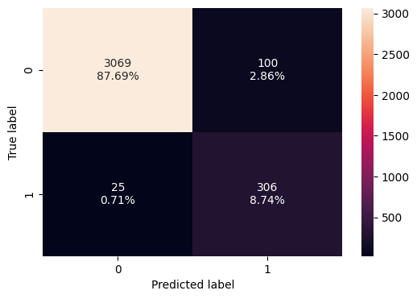

```python
plot_confusion_matrix(dtree_model4, X_train, y_train)
```

Calculate Performance matrix (Accurancy, recall, precision and f1)

```python
dtree4_train_perf_tuned = model_performance_classification(
    dtree_model4, X_train, y_train
)
dtree4_train_perf_tuned
```

|  | Accuracy | Recall | Precision | F1 |
| --- | --- | --- | --- | --- |
| 0 | 0.964286 | 0.924471 | 0.753695 | 0.830393 |

** Visualize the tree **

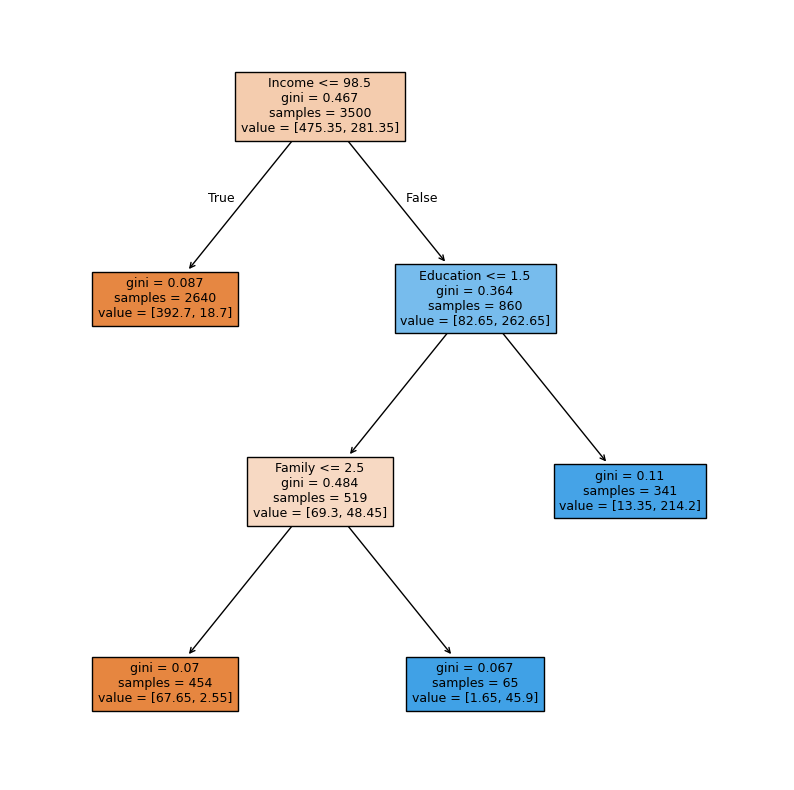

```python
plt.figure(figsize=(10, 10))
out = tree.plot_tree(
    dtree_model4,
    feature_names=feature_names,
    filled=True,
    fontsize=9,
    node_ids=False,
    class_names=None,
)
# below code will add arrows to the decision tree split if they are missing
for o in out:
    arrow = o.arrow_patch
    if arrow is not None:
        arrow.set_edgecolor("black")
        arrow.set_linewidth(1)
plt.show()
```

**Observations**

- This is a far less complex tree than the previous one.
- The model used only Income, Education and Family to determine whether the application will be approved or not.
- It also gives highly generalized results, which is better and avoids overfitting.

```python
print(tree.export_text(dtree_model4, feature_names=feature_names, show_weights=True))
```

```
|--- Income <= 98.50
|   |--- weights: [392.70, 18.70] class: 0
|--- Income >  98.50
|   |--- Education <= 1.50
|   |   |--- Family <= 2.50
|   |   |   |--- weights: [67.65, 2.55] class: 0
|   |   |--- Family >  2.50
|   |   |   |--- weights: [1.65, 45.90] class: 1
|   |--- Education >  1.50
|   |   |--- weights: [13.35, 214.20] class: 1
```

```python
# importance of features in the tree building ( The importance of a feature is computed as the
# (normalized) total reduction of the criterion brought by that feature. It is also known as the Gini importance )

print(
    pd.DataFrame(
        dtree_model4.feature_importances_, columns=["Imp"], index=X_train.columns
    ).sort_values(by="Imp", ascending=False)
)
```

```
                         Imp
Income              0.674921
Family              0.171953
Education           0.153126
ID                  0.000000
ZIPCode             0.000000
Age                 0.000000
CCAvg               0.000000
Mortgage            0.000000
Securities_Account  0.000000
CD_Account          0.000000
Online              0.000000
CreditCard          0.000000
```

```python
# importance of features in the tree building
importances = dtree_model4.feature_importances_
indices = np.argsort(importances)

plt.figure(figsize=(8, 8))
plt.title("Feature Importances")
plt.barh(range(len(indices)), importances[indices], color="violet", align="center")
plt.yticks(range(len(indices)), [feature_names[i] for i in indices])
plt.xlabel("Relative Importance")
plt.show()
```

[output not shown]

**Observations**

- After post-pruning on Recall score, Income, Education and Family are the most influential attributes that contributes in determining loan approval decision This has also simplified the tree using only three parameters

** Checking performance on test data**

```python
plot_confusion_matrix(dtree_model4, X_test, y_test)
```

[output not shown]

2. Calculate Performance matrix (Accuracy, Recall, Precision, F1)

```python
dtree4_test_perf_tuned_post2 = model_performance_classification(
    dtree_model4, X_test, y_test
)
dtree4_test_perf_tuned_post2
```

|  | Accuracy | Recall | Precision | F1 |
| --- | --- | --- | --- | --- |
| 0 | 0.963333 | 0.892617 | 0.773256 | 0.82866 |

3. Model Performance Comparison and Final Model Selection - Training Performance Comparison

```python
# training performance comparison

models_train_comp_df = pd.concat(
    [

        decision_tree_perf_train.T,  # Transpose the performance DataFrame
        dtree2_train_perf_tuned.T,  # Transpose the performance DataFrame
        dtree3_train_perf_tuned.T,  # Transpose the performance DataFrame
        dtree4_train_perf_tuned.T,  # Transpose the performance DataFrame

    ],
    axis=1,
)
models_train_comp_df.columns = [
    "Decision Tree (sklearn default)",
    "Decision Tree (Pre-Pruning)",
    "Decision Tree (Post-Pruning-1)",
    "Decision Tree (Post-Pruning-2)",
]
print("Training performance comparison:")
models_train_comp_df
```

```
Training performance comparison:
```

|  | Decision Tree (sklearn default) | Decision Tree (Pre-Pruning) | Decision Tree (Post-Pruning-1) | Decision Tree (Post-Pruning-2) |
| --- | --- | --- | --- | --- |
| Accuracy | 1.0 | 0.988857 | 0.996000 | 0.964286 |
| Recall | 1.0 | 0.915408 | 0.972810 | 0.924471 |
| Precision | 1.0 | 0.964968 | 0.984709 | 0.753695 |
| F1 | 1.0 | 0.939535 | 0.978723 | 0.830393 |

** Observations**

- The recall value on test data set for post-pruning model is lower than that of training data set.
- The post-pruning model based on recall value is recommended considering it also generates very simple tree

** Model Performance Comparison and Final Model Selection - Test Performance Comparison **

```python
# testing performance comparison

models_test_comp_df = pd.concat(
    [decision_tree_perf_test.T, decision_tree_perf_test_tuned.T, dtree3_test_perf_tuned_post1.T, dtree4_test_perf_tuned_post2.T], axis=1,
)
models_test_comp_df.columns = ["Decision Tree (sklearn default)", "Decision Tree (Pre-Pruning)", "Decision Tree (Post-Pruning-1)", "Decision Tree (Post-Pruning-2)"]
print("Test set performance comparison:")
models_test_comp_df
```

```
Test set performance comparison:
```

|  | Decision Tree (sklearn default) | Decision Tree (Pre-Pruning) | Decision Tree (Post-Pruning-1) | Decision Tree (Post-Pruning-2) |
| --- | --- | --- | --- | --- |
| Accuracy | 0.978667 | 0.982000 | 0.984667 | 0.963333 |
| Recall | 0.892617 | 0.872483 | 0.892617 | 0.892617 |
| Precision | 0.892617 | 0.942029 | 0.950000 | 0.773256 |
| F1 | 0.892617 | 0.905923 | 0.920415 | 0.828660 |

Predicting the data point

```python
%%time
# choosing a data point
applicant_details = X_test.iloc[20:21, :]

# making a prediction
approval_prediction = dtree_model4.predict(applicant_details)

print(approval_prediction)
```

```
[0]
CPU times: user 2.21 ms, sys: 0 ns, total: 2.21 ms
Wall time: 2.18 ms
```

- Checking random 20th row for applicant
- The model was able to predict in less than ~5ms seconds.
- Instead of predicting a class (approve/reject), the model can also predict the likelihood of approval.
- Making a prediction

```python
# making a prediction
approval_likelihood = dtree_model4.predict_proba(applicant_details)

print(approval_likelihood[0, 0])
```

[output not shown]

** Observations *